# rNADEF Workbook

North American Dendroecological Fieldweek *Stockton Maxwell, Grant Harley, Chris Gentry, and data from many others

# 1 Packages Used in this Document

There are a number of useful packages for manipulating and analyzing data in **R**. In this document we will use a few of the primary packages specific to tree-ring analysis.

- dplR
- treeclim
- graphics
- utils
- TRADER
- burnr
- ggplot2

If you do not have one or many of these packages installed you can add them by using `install.packages(x)` function where *x* is the name of the package you desire to install.

```r
library(dplR)
library(treeclim)
library(graphics)
library(utils)
library(TRADER)
library(burnr)
library(ggplot2)
```

# 2 COFECHA in dplR

Using the script below, you will be able to read in raw ring width files for *COFECHA*-like analysis. To run your own data, change the `fname` to match the data in your `data <- read.rwl(fname = ... , format = "auto")` script.

```r
grow.rwl <- read.rwl(fname = "wa091.rwl", format = "auto") #fname can be changed to run your data
```

```
Attempting to automatically detect format.
Assuming a Tucson format file.
There appears to be a header in the rwl file
There are 44 series
1       TCT190A      1609    1987   0.01
2       TCT190B      1584    1987   0.01
3       TCT191A      1608    1987   0.01
4       TCT191B      1638    1987   0.01
5       TCT192A      1556    1987   0.01
6       TCT192B      1596    1987   0.01
7       TCT193A      1592    1986   0.01
8       TCT194A      1693    1986   0.01
9       TCT194B      1691    1987   0.01
10      TCT195A      1608    1987   0.01
11      TCT195B      1601    1987   0.01
```

[output cut: 33 more lines]

```r
rwl.stats(grow.rwl) #summary and stats of raw ring width file
```

| series | first | last | year | mean | median | stdev | skew | gini | ar1 |
| --- | --- | --- | --- | --- | --- | --- | --- | --- | --- |
| TCT190A | 1609 | 1987 | 379 | 0.897 | 0.830 | 0.419 | 0.791 | 0.259 | 0.869 |
| TCT190B | 1584 | 1987 | 404 | 0.980 | 0.950 | 0.393 | 0.491 | 0.226 | 0.898 |
| TCT191A | 1608 | 1987 | 380 | 0.745 | 0.520 | 0.573 | 1.062 | 0.411 | 0.896 |
| TCT191B | 1638 | 1987 | 350 | 0.806 | 0.495 | 0.715 | 1.826 | 0.429 | 0.897 |
| TCT192A | 1556 | 1987 | 432 | 0.493 | 0.310 | 0.541 | 3.011 | 0.439 | 0.918 |
| TCT192B | 1596 | 1987 | 392 | 0.438 | 0.390 | 0.223 | 1.351 | 0.271 | 0.881 |
| TCT193A | 1592 | 1986 | 395 | 0.616 | 0.510 | 0.382 | 0.883 | 0.341 | 0.855 |
| TCT194A | 1693 | 1986 | 294 | 0.826 | 0.795 | 0.238 | 0.660 | 0.160 | 0.678 |
| TCT194B | 1691 | 1987 | 297 | 0.941 | 0.920 | 0.238 | 0.877 | 0.138 | 0.570 |
| TCT195A | 1608 | 1987 | 380 | 1.021 | 0.930 | 0.355 | 1.227 | 0.186 | 0.816 |

[output cut: 34 more lines]

You can plot this information to view the time series and/or skeleton plot of a series.

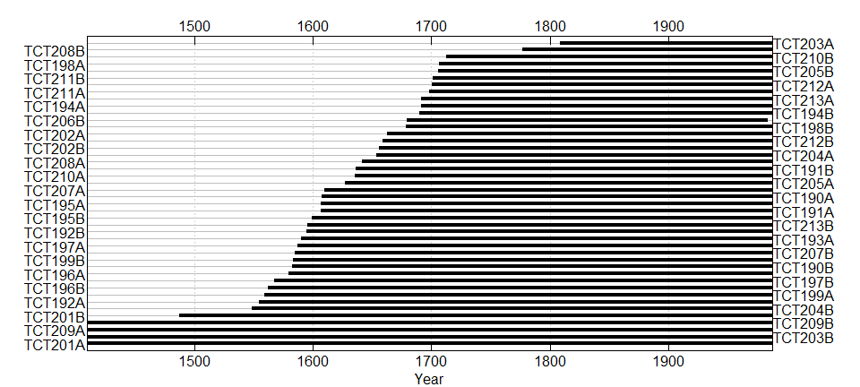

```r
seg.plot(grow.rwl) #plot of series time spans
```

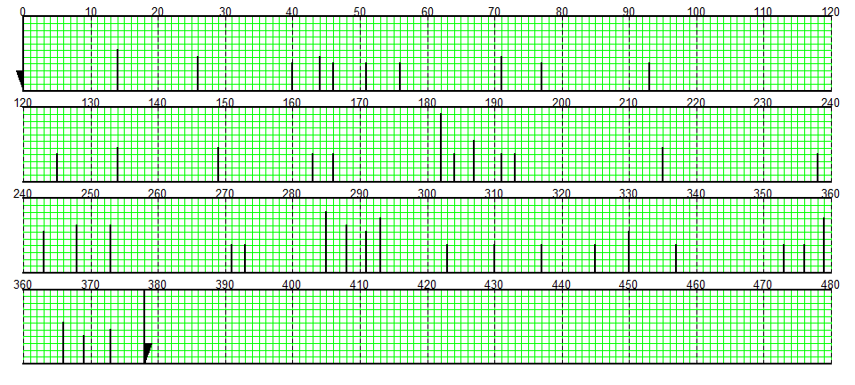

```r
skel.plot(grow.rwl[1]) #skeleton plot of an individual series, where [1] identifies the first record in grow.rwl
```

You can also examine the common time interval, radii for each series, and mean sensitivity of the rwl.

```r
data.frame(colSums(grow.rwl, na.rm = TRUE, dims = 1)) #get radii length in mm
```

|  | colSums.grow.rwl..na.rm...TRUE..dims...1. |
| --- | --- |
| TCT190A | 339.90 |
| TCT190B | 395.81 |
| TCT191A | 283.11 |
| TCT191B | 282.00 |
| TCT192A | 212.82 |
| TCT192B | 171.63 |
| TCT193A | 243.41 |
| TCT194A | 242.80 |
| TCT194B | 279.55 |
| TCT195A | 387.85 |

[output cut: 34 more lines]

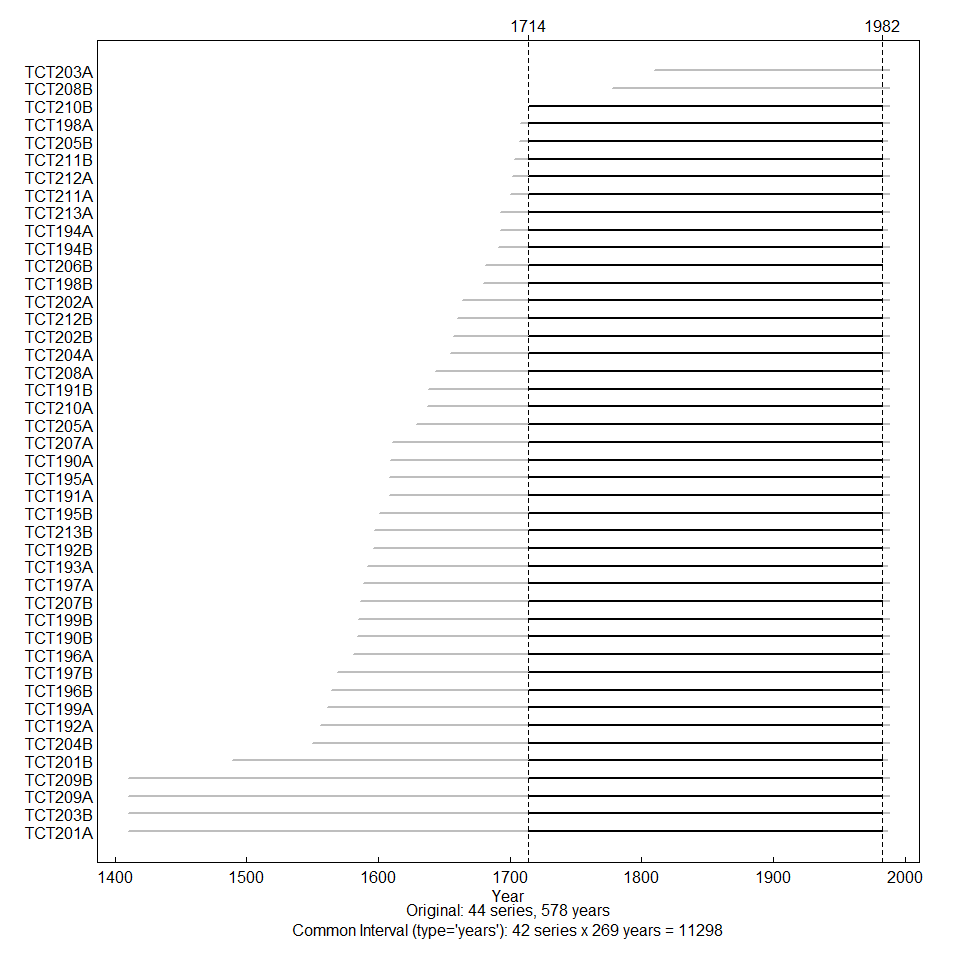

```r
wa091.common <- common.interval(grow.rwl, type=c("years"), make.plot=TRUE) #find common time interval
```

```r
sens1(grow.rwl) #calculate mean sensitivity
```

```
[1] 0.2052919
```

# 3 Crossdating

Using functions from **dplR** you can also obtain *COFECH*-like output.

```
$spearman.rho
        1500.1549 1525.1574 1550.1599 1575.1624 1600.1649 1625.1674 1650.1699 1675.1724 1700.1749 1725.1774 1750.1799
TCT190A        NA        NA        NA        NA        NA 0.6193037 0.5586074 0.5013685 0.5278752 0.5292197 0.4022569
TCT190B        NA        NA        NA        NA 0.4252101 0.6946939 0.6800000 0.6979592 0.7370468 0.7471309 0.7580792
TCT191A        NA        NA        NA        NA        NA 0.5443938 0.5076110 0.4682353 0.5256663 0.3944778 0.3917887
TCT191B        NA        NA        NA        NA        NA        NA 0.4929172 0.5560144 0.4476831 0.4247299 0.6750060
TCT192A        NA        NA        NA 0.5329652 0.4909004 0.4084994 0.4256903 0.3557743 0.2257383 0.4837571 0.3375270
TCT192B        NA        NA        NA        NA        NA 0.5896279 0.3850660 0.3080432 0.3684514 0.5131813 0.3574070
TCT193A        NA        NA        NA        NA        NA 0.4933013 0.6153661 0.5213445 0.3708523 0.5493878 0.5956783
TCT194A        NA        NA        NA        NA        NA        NA        NA        NA 0.5948139 0.6221849 0.6020168
TCT194B        NA        NA        NA        NA        NA        NA        NA        NA 0.5209604 0.6827535 0.6798723
TCT195A        NA        NA        NA        NA        NA 0.7330132 0.5672509 0.3978391 0.6407203 0.6765426 0.6248739
TCT195B        NA        NA        NA        NA        NA 0.6202641 0.4650660 0.4453782 0.6606002 0.5838655 0.5233613
TCT196A        NA        NA        NA        NA 0.4961825 0.4692917 0.6000960 0.6263145 0.6218007 0.6389916 0.6199760
TCT196B        NA        NA        NA 0.3145738 0.2906603 0.3275390 0.3203361 0.4000480 0.5524610 0.4945498 0.3733493
TCT197A        NA        NA        NA        NA 0.7057383 0.6326531 0.4644898 0.3977431 0.6471549 0.7722929 0.6053782
TCT197B        NA        NA        NA        NA 0.2717407 0.4605522 0.6192077 0.5878031 0.5383433 0.6563745 0.7353181
TCT198A        NA        NA        NA        NA        NA        NA        NA        NA        NA 0.6526927 0.5955628
TCT198B        NA        NA        NA        NA        NA        NA        NA        NA 0.3988956 0.4682353 0.4778391
TCT199A        NA        NA        NA 0.5160624 0.3722929 0.3455942 0.5771429 0.7302281 0.6917167 0.4412485 0.4516206
TCT199B        NA        NA        NA        NA 0.5078031 0.5978872 0.6688595 0.5642737 0.4352941 0.4513325 0.5808884
TCT201A 0.5299880 0.6012485 0.6207443 0.7040096 0.6350540 0.4920528 0.5395918 0.5650420 0.7687395 0.7085234 0.6214166
TCT201B 0.5148139 0.6074910 0.4628571 0.4634334 0.3540456 0.2456182 0.3593277 0.5878992 0.6140216 0.5835774 0.4747659
TCT202A        NA        NA        NA        NA        NA        NA        NA 0.5914526 0.5711885 0.4154142 0.6338055
TCT202B        NA        NA        NA        NA        NA        NA        NA 0.5554382 0.3723890 0.2955582 0.4819688
TCT203A        NA        NA        NA        NA        NA        NA        NA        NA        NA        NA        NA
TCT203B 0.4353902 0.5296999 0.5685954 0.6564706 0.3573109 0.2986315 0.5151981 0.4769748 0.4688115 0.5448739 0.6950780
TCT204A        NA        NA        NA        NA        NA        NA        NA 0.5927971 0.6794238 0.5730132 0.5594718
TCT204B        NA        NA        NA 0.4519088 0.5368067 0.4471068 0.4599760 0.4386555 0.4036014 0.5248019 0.5644658
TCT205A        NA        NA        NA        NA        NA        NA 0.4347179 0.4759184 0.5749340 0.6163265 0.4035054
TCT205B        NA        NA        NA        NA        NA        NA        NA        NA        NA 0.6218968 0.5188475
TCT206B        NA        NA        NA        NA        NA        NA        NA        NA 0.7479952 0.7342617 0.7219688
TCT207A        NA        NA        NA        NA        NA 0.5829052 0.4881152 0.6035534 0.6841297 0.6528211 0.6533013
TCT207B        NA        NA        NA        NA 0.5397839 0.5306603 0.5295078 0.5617767 0.6159424 0.4619928 0.2824970
TCT208A        NA        NA        NA        NA        NA        NA 0.3030492 0.5733013 0.6904682 0.6387995 0.6308283
TCT208B        NA        NA        NA        NA        NA        NA        NA        NA        NA        NA        NA
TCT209A 0.5608163 0.6136375 0.4450900 0.2673229 0.3378151 0.1534214 0.1908764 0.3935174 0.3971669 0.5044418 0.5358463
TCT209B 0.5121248 0.5225930 0.4658343 0.4535414 0.3993758 0.2927731 0.4559424 0.4526771 0.3634574 0.5563025 0.5992317
TCT210A        NA        NA        NA        NA        NA        NA 0.6093157 0.3741176 0.2701080 0.4024490 0.5402641
TCT210B        NA        NA        NA        NA        NA        NA        NA        NA        NA        NA 0.5210564
```

[output cut: 257 more lines]

```
 [4,] 1575 1624
 [5,] 1600 1649
 [6,] 1625 1674
 [7,] 1650 1699
 [8,] 1675 1724
 [9,] 1700 1749
[10,] 1725 1774
[11,] 1750 1799
[12,] 1775 1824
[13,] 1800 1849
[14,] 1825 1874
[15,] 1850 1899
[16,] 1875 1924
[17,] 1900 1949
[18,] 1925 1974
```

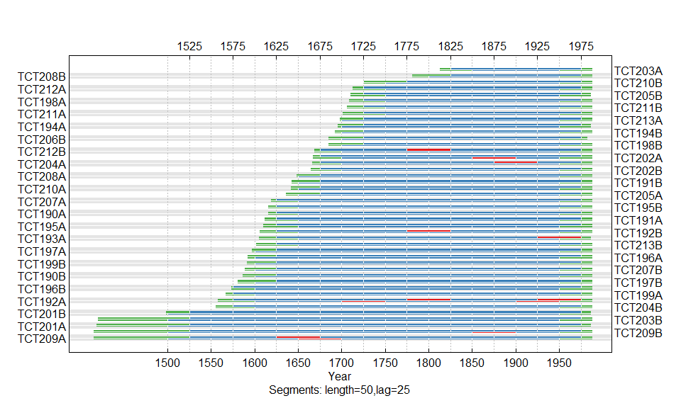

```r
#essentially COFECHA
corr.rwl.seg(rwl = grow.rwl, seg.length = 50, bin.floor = 100, n = NULL, prewhiten = TRUE, pcrit = 0.05,
             biweight = TRUE, method = c("spearman"), make.plot = TRUE, label.cex = 1, floor.plus1 = FALSE,
             master = NULL)
```

```
$series
     1667      1668      1669      1670      1671      1672      1673      1674      1675      1676      1677      1678
0.5971782 0.7116122 0.7787167 0.8890390 0.9548299 1.1663620 1.3170583 1.0353979 0.7167068 1.1664250 0.9859545 1.5341039
     1679      1680      1681      1682      1683      1684      1685      1686      1687      1688      1689      1690
1.1730966 0.7589083 1.1337845 1.8681060 1.1170355 0.8102020 1.3719490 0.9744205 1.7323735 0.3735537 0.6329347 1.1198198
     1691      1692      1693      1694      1695      1696      1697      1698      1699      1700      1701      1702
0.7271111 1.4251640 1.2162986 0.8910023 1.2111579 1.1084111 0.6164988 1.0853554 1.5140716 1.2210475 0.7388059 0.5762757
     1703      1704      1705      1706      1707      1708      1709      1710      1711      1712      1713      1714
0.8424514 0.7447867 1.2060950 1.3373410 1.3682630 0.6649315 0.9745860 1.2512185 0.5921076 0.7498705 1.2038509 1.6035273
     1715      1716      1717      1718      1719      1720      1721      1722      1723      1724      1725      1726
1.6937455 1.0696175 1.1629932 1.3056609 0.9075440 1.7408271 1.0774798 1.9103916 0.7893103 1.4249733 0.3488100 0.5238013
     1727      1728      1729      1730      1731      1732      1733      1734      1735      1736      1737      1738
0.6055941 0.7519155 0.9860599 0.9540938 0.8577085 0.9646317 0.9160965 1.2307535 1.2604881 0.7031361 1.2868468 0.9440966
     1739      1740      1741      1742      1743      1744      1745      1746      1747      1748      1749      1750
0.7018170 0.9983312 0.7576517 1.2329450 1.0916407 0.9814241 1.0303990 0.6128166 1.1771510 0.8840900 0.8895280 1.2944680
     1751      1752      1753      1754      1755      1756      1757      1758      1759      1760      1761      1762
0.8280509 1.4211365 0.7995740 0.7839236 1.3882069 1.0097173 1.2415444 1.1602507 1.3600354 0.6665433 0.5575218 1.2551907
     1763      1764      1765      1766      1767      1768      1769      1770      1771      1772      1773      1774
0.9211816 1.0078292 1.0515088 1.0641772 1.2474994 0.9913651 1.0569702 1.7396617 1.3279033 0.5683328 1.6606870 1.1012156
     1775      1776      1777      1778      1779      1780      1781      1782      1783      1784      1785      1786
0.9638236 0.2558945 1.3877788 0.7840787 1.2232514 1.1255480 0.6317434 0.4026679 1.0523527 1.2829196 1.7530957 1.2991619
     1787      1788      1789      1790      1791      1792      1793      1794      1795      1796      1797      1798
0.6198167 1.1029976 1.2797162 1.0596618 0.6736372 1.3591753 1.1040603 1.0916896 0.8980498 0.7638595 0.9715644 1.0636370
     1799      1800      1801      1802      1803      1804      1805      1806      1807      1808      1809      1810
0.9145714 0.7649497 1.4480627 0.8256506 0.8645272 1.5531550 1.5134229 1.0063336 0.9299876 1.0296321 0.7624750 0.5621470
     1811      1812      1813      1814      1815      1816      1817      1818      1819      1820      1821      1822
0.6789251 1.0107603 0.9668071 0.8902483 0.9518823 0.8738479 1.2500217 0.9534054 1.0279194 0.8358793 0.8649887 0.9461722
     1823      1824      1825      1826      1827      1828      1829      1830      1831      1832      1833      1834
0.8640277 1.0560339 1.5842245 0.8893983 0.6863850 0.6482509 1.2291355 0.8592098 1.3234410 0.9194689 1.2015615 1.1883969
     1835      1836      1837      1838      1839      1840      1841      1842      1843      1844      1845      1846
0.8650605 0.8130885 0.9747986 0.7881019 1.0502725 0.7981516 0.6630823 0.9129576 0.9964319 0.8520390 1.3294439 0.9682829
     1847      1848      1849      1850      1851      1852      1853      1854      1855      1856      1857      1858
0.8903450 1.1732093 0.7941180 1.0812335 1.0609452 1.0502897 0.9076944 0.9219167 0.9491671 0.9677115 1.0489603 0.8370706
     1859      1860      1861      1862      1863      1864      1865      1866      1867      1868      1869      1870
0.9882291 1.0122370 0.8887049 0.9226013 1.1564657 0.5033949 0.8803937 1.3217717 0.7483345 0.9455910 1.0811227 0.9405660
     1871      1872      1873      1874      1875      1876      1877      1878      1879      1880      1881      1882
1.1414753 0.5737180 0.8682969 0.9685588 1.0261016 0.8258351 0.8372522 1.0380172 0.8947509 0.7317391 0.9239124 1.1253135
     1883      1884      1885      1886      1887      1888      1889      1890      1891      1892      1893      1894
1.1087398 1.1104220 0.8191150 0.9776097 0.8737654 1.0466600 1.1148361 0.8714098 0.8071657 0.8946615 1.1964912 0.7263518
     1895      1896      1897      1898      1899      1900      1901      1902      1903      1904      1905      1906
```

[output cut: 56 more lines]

```
0.8420087 1.0022723 0.7914111 1.1268210 0.9419848 1.0959077 1.0939624 0.9130812 0.9326469 1.1827915 0.8781466 0.9337249
     1907      1908      1909      1910      1911      1912      1913      1914      1915      1916      1917      1918
0.8762385 1.0097415 0.8943281 0.9599541 1.0605355 0.8996713 1.0274126 0.9897450 1.0043557 0.9103143 0.9671491 0.8593213
     1919      1920      1921      1922      1923      1924      1925      1926      1927      1928      1929      1930
1.0726755 1.1062079 0.9350622 0.9404312 0.8821895 0.9354315 1.0181058 0.9090544 1.0003699 0.9812399 0.9356015 0.9024932
     1931      1932      1933      1934      1935      1936      1937      1938      1939      1940      1941      1942
1.0661779 0.9488352 1.1219630 0.9721716 1.1127882 0.7266564 0.9272982 1.0511755 0.8198507 1.0885784 1.1004664 1.0606606
     1943      1944      1945      1946      1947      1948      1949      1950      1951      1952      1953      1954
1.0028107 1.0686355 0.9207292 0.9007754 0.9230849 1.2027394 0.8172244 1.0397410 0.8937249 0.9389980 0.9732394 0.9637481
     1955      1956      1957      1958      1959      1960      1961      1962      1963      1964      1965      1966
1.0593064 0.7833610 0.8718024 1.0557877 0.8528153 0.9950629 1.0426821 0.8186604 1.0517565 1.1043023 0.9801978 0.9061814
     1967      1968      1969      1970      1971      1972      1973      1974      1975      1976      1977      1978
0.9963353 0.8988739 0.9715841 1.1491948 0.8665632 0.9321336 0.9783374 0.8956546 0.9306991 1.0580949 1.0341696 0.9079530
     1979      1980      1981      1982      1983      1984      1985      1986      1987
0.9575313 1.0763050 1.0698305 0.9505808 1.0049607 1.0248524 0.7781505 0.9397957 0.8090673
```

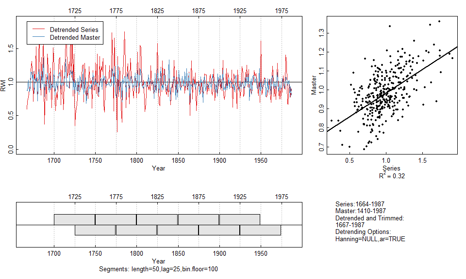

```r
#examine an individual series
series.rwl.plot(grow.rwl, series = "TCT202A", series.yrs = as.numeric(names(series)),
                seg.length = 50, bin.floor = 100, n = NULL,
                prewhiten = TRUE, biweight = TRUE, floor.plus1 = FALSE)
```

## 3.1 Spaghetti plot of raw ring widths

Frequently you will see a plot of the raw ring widths of all series on the same graph. These *spaghetti plots* can be created using the `spag.plot()` function in **dplR**.

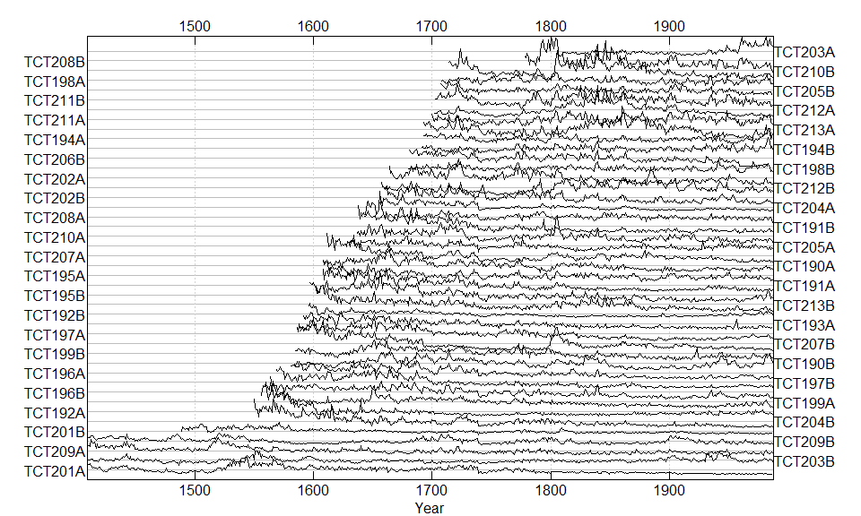

```r
spag.plot(rwl = grow.rwl, zfac = 1, useRaster = FALSE, res = 300)
```

### 3.1.1 Calculate marker rings from raw ring width series

markers <- pointer(grow.rwl)